# Lesson 5 - Machine Learning with R

## Learning objectives

After this lesson:

- You will be able to explore data suited for training a machine learning algorithm
- Perform a number of unsupervised exploratory analysis (PCA, t-SNE, k-Means)
- Build a predictive toxicity model, based on chemical fingerprints
- Build a model to predict the partition coefficient (LogP), based on fingerprints
- Enrich your data using an external data source (Tox21 dataset)
- (Perform a biological read across, based on compound similarity)

## Learning more; TAME

If after this course you would like to learn more about applying ML in Toxicology, the [The TAME Toolkit](https://github.com/UNCSRP/Data-Analysis-Training-Modules) for Introductory Data Science, Chemical-Biological Analyses, Predictive Modeling, and Database Mining for Environmental Health Research is a good place to start learning. Some of the examples in this lesson were taken from [chapter 2.2 of the TAME Bookdown project](https://uncsrp.github.io/Data-Analysis-Training-Modules/machine-learning-and-predictive-modeling.html#machine-learning-and-predictive-modeling)

[Reference:](https://doi.org/10.3389/ftox.2022.893924) Roell, K., Koval, L. E., Boyles, R., Patlewicz, G., Ring, C., Rider, C. V., Ward-Caviness, C., Reif, D. M., Jaspers, I., Fry, R. C., & Rager, J. E. (2022). Development of the InTelligence And Machine LEarning (TAME) Toolkit for Introductory Data Science, Chemical-Biological Analyses, Predictive Modeling, and Database Mining for Environmental Health Research. Frontiers in toxicology, 4, 893924. https://doi.org/10.3389/ftox.2022.893924

## Tidymodels

The Tidymodels framework is an extension of the `{tidyverse}` suite. It is especially focused towards providing a generalized way to define, run and optimize models in R. To get started we will walk you though the ‘getting started’ part of the [Tidymodels documentation](https://www.tidymodels.org/start/)

To learn more on Tidymodels, there is a very elaborate [bookdown project](https://www.tmwr.org)

## Packages

```r
library(tidymodels)
library(tidyverse)
library(broom.mixed) # for converting bayesian models to tidy tibbles
library(dotwhisker)  #
```

## Data

For this lesson we will use a number of different datasets. Because we need datasets that include somewhat larger volumes of data, we also download data on the fly.

Let’s get the datasets

### Sea Urchins

A dataset build into the `{tidymodels}` documentation for illustrative purposes. See [original resource:](https://www.tidymodels.org/start/models/)

```r
urchins <-
  # Data were assembled for a tutorial
  # at https://www.flutterbys.com.au/stats/tut/tut7.5a.html
  read_csv("https://tidymodels.org/start/models/urchins.csv") %>%
  # Change the names to be a little more verbose
  setNames(c("food_regime", "initial_volume", "width")) %>%
  # Factors are very helpful for modeling, so we convert one column
  mutate(food_regime = factor(food_regime, levels = c("Initial", "Low", "High")))
```

### Chemical_Lists_PFAS-Statins from the EPA

This datset was curated and povided in the TAME project mentioned above It can be directly downloaded from Github

```r
url <- "https://raw.githubusercontent.com/UNCSRP/Data-Analysis-Training-Modules/main/Chapter%202/2.2%20ML%20Predictive%20Modeling/Module2_2_Chemical_Lists_PFAS-Statins.csv"

data_tame <- read_csv(
    url,
    locale = readr::locale(encoding ="UTF-8")
    )
```

### Tox21 end Chembl, using the [biobricks.ai bricks](https://biobricks.ai/)

Biobricks.ai is developed by researcher Dr. Tom Luechtefeld as a ‘data-as-dependency’ approach. By integrating large public databases into so-called bricks, the database data can be accessed through a standardized api and downloaded to a local machine or Virtual Machine. The bricks are version controlled, so this enables a reproducible workflow. We will not use this data in this lesson, but it will get you started in finding and downloading data for your own modelling purposes. To get started on Biobricks, the code below will get you the ‘tox21’ brick.

```r
biobricks::local_bblib()
initialize()
brick_install("tox21")
brick_pull("tox21") # OR build it with brick_repro("HGNC")
tbls <- brick_load_arrow("tox21")
names(tbls) # "hgnc_complete_set.parquet"

## look at one table

tox21_tbls  <- purrr::imap_dfr(tbls,~ tibble(tbl=.y,rows=nrow(.x))) |> arrange(desc(rows))
tox21_names <- purrr::imap_dfr(tbls,~ tibble(tbl=.y,name=names(.x)))

ids <- tox21_names |> filter(grepl("ID$",name))
ids <- ids |> split(ids$name) |> discard(~nrow(.)<2)
names(ids)
tox21_names

## look at one table
x <- tbls$`tox21-ache-p3.aggregrated.parquet` |> dplyr::collect()
x

data_all <-
  map(
    .x = tbls,
    .f = dplyr::collect
  )
```

## QSAR data

An example dataset that contains classical chemical fingerprints. [From the UCL repository](https://archive.ics.uci.edu/ml/datasets/QSAR+oral+toxicity)

Metadata: Attribute Information:

1024 binary molecular fingerprints and 1 experimental class: 1-1024) binary molecular fingerprint 1025) experimental class: positive (very toxic) and negative (not very toxic)

Relevant Papers:

[D. Ballabio, F. Grisoni, V. Consonni, R. Todeschini (2019), Integrated QSAR models to predict acute oral systemic toxicity, Molecular Informatics, 38, 180012; doi: 10.1002/minf.201800124](https://doi.org/10.1002/minf.201800124)

Files `ID.txt`,`class.csv` and `X.csv` in folder `./data/lesson5/qsar` were obtained from the author of the paper above via personal communication. Orinal sources files (Matlab scripts and matrix files can be downloaded from the paper’s DOI as supplemental data). They are included here for reproducibility reasons in `./data/lesson5/qsar/oral_toxicity_data.rar`

The code below downloads the data to a the `./data` folder and unzips the file in a temporary folder. We read the file into R from that temp file.

```r
library(archive)
tf <- tempfile()
td <- tempdir()
file.path <- here::here(
  "data",
  "lesson5",
  "qsar",
  "qsar_oral_toxicity.zip"
)

download.file(url = "https://archive.ics.uci.edu/ml/machine-learning-databases/00508/qsar_oral_toxicity.zip", destfile = file.path)

unzip(zipfile = file.path, exdir = td)
td
```

```
## [1] "/var/folders/dh/8nqm587d06s2t64pyz6ch17m0000gn/T//RtmpgL5KJd"
```

```r
list.files(td)
```

[output not shown]

[output cut: 277 more lines]

## Getting started with `{tidymodels}`

The fragment below was reproduced from [the `tidymodels` documentation](https://www.tidymodels.org/start/models/)

### Build our first model with Tidymodels

```r
urchins
```

```
## # A tibble: 72 × 3
##    food_regime initial_volume width
##    <fct>                <dbl> <dbl>
##  1 Initial                3.5 0.01
##  2 Initial                5   0.02
##  3 Initial                8   0.061
##  4 Initial               10   0.051
##  5 Initial               13   0.041
##  6 Initial               13   0.061
##  7 Initial               15   0.041
##  8 Initial               15   0.071
##  9 Initial               16   0.092
## 10 Initial               17   0.051
## # … with 62 more rows
```

Plotting the data As a first step in modeling, it’s always a good idea to plot the data:

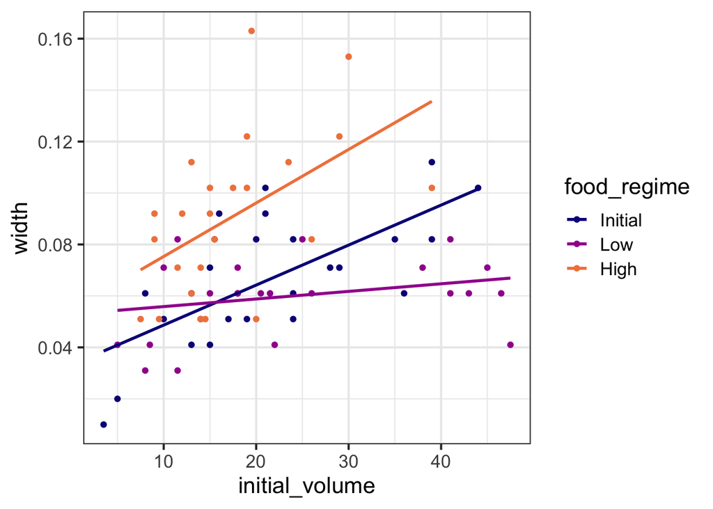

```r
ggplot(urchins,
       aes(x = initial_volume,
           y = width,
           group = food_regime,
           col = food_regime)) +
  geom_point() +
  geom_smooth(method = lm, se = FALSE) +
  scale_color_viridis_d(option = "plasma", end = .7)
```

A standard two-way analysis of variance (ANOVA) model makes sense for this dataset because we have both a continuous predictor and a categorical predictor. Since the slopes appear to be different for at least two of the feeding regimes, let’s build a model that allows for two-way interactions. Specifying an R formula with our variables in this way:

$width \sim initial\_volume * food\_regime$, where the $\sim$ means ‘is dependent on’.

If we put this together we can define the linear regression model (using the ‘ordinal least squares’ engine) as:

```r
linear_reg() |>
  set_engine("lm")
```

```
## Linear Regression Model Specification (regression)
##
## Computational engine: lm
```

```r
## because "lm" is the default engine this is the same as
linear_reg()
```

```
## Linear Regression Model Specification (regression)
##
## Computational engine: lm
```

We can choose a different computational ‘engine’ as

```r
linear_reg() |>
  set_engine("keras")
```

```
## Linear Regression Model Specification (regression)
##
## Computational engine: keras
```

The [documentation page](https://parsnip.tidymodels.org/reference/linear_reg.html) for `linear_reg()` lists all the possible engines. We’ll save our model object using the default engine as lm_mod.

```r
lm_mod <- linear_reg()
```

From here, the model can be estimated or trained using the fit() function:

```r
lm_fit <-
  lm_mod %>%
  fit(width ~ initial_volume * food_regime, data = urchins)
lm_fit
```

```
## parsnip model object
##
##
## Call:
## stats::lm(formula = width ~ initial_volume * food_regime, data = data)
##
## Coefficients:
##                    (Intercept)                  initial_volume                  food_regimeLow                 food_regimeHigh
##                      0.0331216                       0.0015546                       0.0197824                       0.0214111
##  initial_volume:food_regimeLow  initial_volume:food_regimeHigh
##                     -0.0012594                       0.0005254
```

### Defining a models using `{recipes}`

### Fitting a model

##### Exercise; Getting started with the TAME dataset 5

The TAME learning module contains an example dataset from the EPA containing molecular descriptors of pfas and statins. The data was already downloaded above and should be visible in your Global env. as `data_tame`. If not, look up the code chunk above an rerun it.

1. Inpect the data, using the tools/functions you learned during the course (e.g. `head()`, `skim::skimr()`, `colnames()`, etc.)
2. Check the datatypes of the variables

**Click for the answer**

Exercise

```r
dim(data_tame)
```

```
## [1] 144  14
```

Then looking at the first four rows and five columns of data:

```r
  data_tame[1:4,1:5]
```

```
## # A tibble: 4 × 5
##   List  `Substance Name`                                      CASRN      DTXSID         `Molecular Weight`
##   <chr> <chr>                                                 <chr>      <chr>                       <dbl>
## 1 PFAS  Perfluoro-2-(trifluoromethyl)propanesulphonic acid    93762-09-5 DTXSID90239569               300.
## 2 PFAS  Potassium perfluoroheptanesulfonate                   60270-55-5 DTXSID9069392                488.
## 3 PFAS  Bis(2-hydroxyethyl)ammonium perfluoroheptanesulfonate 70225-15-9 DTXSID60880946               555.
## 4 PFAS  Potassium perfluoro-p-ethylcyclohexanesulfonate       335-24-0   DTXSID50880117               500.
```

Note that the first column, ‘List’, designates the following two larger chemical classes:

```r
unique(data_tame$List)
```

```
## [1] "PFAS"    "Statins"
```

Let’s lastly view all of the column headers:

```r
colnames(data_tame)
```

```
##  [1] "List"                                              "Substance Name"
##  [3] "CASRN"                                             "DTXSID"
##  [5] "Molecular Weight"                                  "OPERA, Boiling Point"
##  [7] "OPERA, Henry's Law Constant"                       "OPERA, Melting Point"
##  [9] "OPERA, Negative Log of Acid Dissociation Constant" "OPERA, Octanol-Air Partition Coefficient"
## [11] "OPERA, Octanol-Water Distribution Coefficient"     "OPERA, Octanol-Water Partition Coefficient"
## [13] "OPERA, Vapor Pressure"                             "OPERA, Water Solubility"
```

##### Exercise 5

1. Inspect the file `qsar_oral_toxicity.csv`, using the `head` command the terminal, or on Windows: open the file with Notepad. Are there headers in this file?
2. Rename the columns with a string from “f1” to “f1025”
3. Reorder the classification column (“f1025”) to be the first column, and rename this column to `class`
4. Look at the dataset
5. Tally the classification column, how many observations of each class do we have? Does this correspond with the meta data on UCL? Do you see a potential problem?
6. Isolate the classification column in a new R object
7. Remove the row with classifications (“f1025”) from the data and store the resulting new dataframe as a matrix, using the `as.matrix()` function.

**Click for the answer**

Reading the data into R. This file has no headers. The last column in the data contains the labels.

```r
data_qsar <- read_csv2(
  file.path(td, "qsar_oral_toxicity.csv"),
  col_names = FALSE)
```

```
## ℹ Using "','" as decimal and "'.'" as grouping mark. Use `read_delim()` for more control.
```

```r
# answer
names_new <- paste0("f", 1:1025)
names(data_qsar) <- names_new
data_qsar <- data_qsar |>
  dplyr::relocate(f1025, .before = f1) |>
  rename(class = f1025)

data_qsar |>
  group_by(class) |>
  tally()
```

```
## # A tibble: 2 × 2
##   class        n
##   <chr>    <int>
## 1 negative  8251
## 2 positive   741
```

```r
classes <- data_qsar$class

#data_qsar_all_numm <- data_qsar |>
#  select(-class)

## look at the data
data_qsar
```

```
## # A tibble: 8,992 × 1,025
##    class      f1    f2    f3    f4    f5    f6    f7    f8    f9   f10   f11   f12   f13   f14   f15   f16   f17   f18   f19   f20
##    <chr>   <dbl> <dbl> <dbl> <dbl> <dbl> <dbl> <dbl> <dbl> <dbl> <dbl> <dbl> <dbl> <dbl> <dbl> <dbl> <dbl> <dbl> <dbl> <dbl> <dbl>
##  1 negati…     0     0     0     0     0     0     0     0     0     0     1     0     0     0     0     0     1     0     0     0
##  2 negati…     0     0     1     0     0     0     0     0     0     0     1     0     0     0     0     0     1     0     0     0
##  3 negati…     0     0     0     0     0     0     0     0     0     0     1     0     0     0     0     0     1     0     0     0
##  4 negati…     0     0     0     0     0     0     0     1     0     0     1     0     0     0     0     0     1     0     0     0
##  5 negati…     0     0     0     0     0     0     0     0     0     0     0     0     0     1     0     0     1     0     0     0
##  6 negati…     1     0     0     0     0     0     1     0     0     0     0     0     0     0     0     0     1     0     0     0
##  7 negati…     0     0     0     0     0     0     0     0     0     0     1     0     0     0     0     0     1     0     0     0
##  8 positi…     0     0     1     0     0     0     0     0     0     0     0     0     0     1     0     0     0     0     0     0
##  9 negati…     0     0     0     0     0     0     0     0     0     0     0     0     0     1     0     0     0     0     0     0
## 10 negati…     0     0     0     0     0     0     0     0     0     0     0     0     0     0     0     0     0     0     0     0
## # … with 8,982 more rows, and 1,004 more variables: f21 <dbl>, f22 <dbl>, f23 <dbl>, f24 <dbl>, f25 <dbl>, f26 <dbl>, f27 <dbl>,
## #   f28 <dbl>, f29 <dbl>, f30 <dbl>, f31 <dbl>, f32 <dbl>, f33 <dbl>, f34 <dbl>, f35 <dbl>, f36 <dbl>, f37 <dbl>, f38 <dbl>,
## #   f39 <dbl>, f40 <dbl>, f41 <dbl>, f42 <dbl>, f43 <dbl>, f44 <dbl>, f45 <dbl>, f46 <dbl>, f47 <dbl>, f48 <dbl>, f49 <dbl>,
## #   f50 <dbl>, f51 <dbl>, f52 <dbl>, f53 <dbl>, f54 <dbl>, f55 <dbl>, f56 <dbl>, f57 <dbl>, f58 <dbl>, f59 <dbl>, f60 <dbl>,
## #   f61 <dbl>, f62 <dbl>, f63 <dbl>, f64 <dbl>, f65 <dbl>, f66 <dbl>, f67 <dbl>, f68 <dbl>, f69 <dbl>, f70 <dbl>, f71 <dbl>,
## #   f72 <dbl>, f73 <dbl>, f74 <dbl>, f75 <dbl>, f76 <dbl>, f77 <dbl>, f78 <dbl>, f79 <dbl>, f80 <dbl>, f81 <dbl>, f82 <dbl>,
## #   f83 <dbl>, f84 <dbl>, f85 <dbl>, f86 <dbl>, f87 <dbl>, f88 <dbl>, f89 <dbl>, f90 <dbl>, f91 <dbl>, f92 <dbl>, f93 <dbl>, …
```

## Exploratory Data Analysis

- Use visualisation and transformations to explore your data in a systematic way
- A task that statisticians call exploratory data analysis, or EDA for short.

### EDA is an iterative cycle; you:

1. Generate questions about your data.
2. Search for answers by visualising, transforming, and modelling your data.
3. Use what you learn to refine your questions and/or generate new questions.

**You do not need to know statistics for EDA, but it helps if you do!**

### EDA is not a formal process with a strict set of rules

- EDA is a state of mind.
- Should feel free to investigate every idea that occurs to you.
- Some of these ideas will pan out, and some will be dead ends.
- As your exploration continues, you will zoom in on a few particularly productive areas that you’ll eventually write up and communicate to others.

### EDA Steps

To do data analysis, you’ll need to deploy all the tools of EDA: visualisation, transformation, and modelling.

When perfoming EDA consider

1. What question(s) are you trying to solve (or prove wrong)?
2. Which information do you need and can you come up with a plan to answer the question(s)
3. What kind of data do you have and how do you treat different types?
4. What’s missing from the data and how do you deal with it?
5. Where are the outliers and why should you care about them?
6. How can you add, change or remove features to get more out of your data?
7. Do you need additional data from other sources to relate to the dataset under scrutany?
8. Are underlying statitical assumptions met / how is data distribution looking?
9. What (exploratory) models apply or fit well to the data?
10. What is the undelying (experimental) design?
11. Is there multi-colinearity?

### Definitions

- A **variable** is a quantity, quality, or property that you can measure.
- A **value** is the state of a variable when you measure it. The value of a variable may change from measurement to measurement.
- An **observation** is a set of measurements made under similar conditions. An observation will contain several values, each associated with a different variable. I’ll sometimes refer to an observation as a data point.
- Tables: **Tabular data** is a set of values, each associated with a variable and an observation.
- Tabular data is *tidy* if each value is placed in its own “cell”, each variable in its own column, and each observation in its own row.
- In real-life, most data isn’t tidy, as we’ve seen in **tidy data**.

### Variation

**Variation** is the tendency of the values of a variable to change from measurement to measurement.

- Categorical variables can also vary if you measure across different subjects (e.g. the eye colors of different people), or different times (e.g. the energy levels of an electron at different moments).
- Every variable has its own pattern of variation, which can reveal interesting information. The best way to understand that pattern is to visualise the distribution of the variable’s values.

### Missing values

In a dataset such as this, I do not expect to encouter any missing values. The fingerprints are calculated from molecules, so it would not make sense to have missing values somewhere. But just to be sure, we can get the sum of missing values like this:

```r
sum(is.na(data_qsar))
```

```
## [1] 0
```

One less thing to worry about.

### Distributions

Here we have a distribution of either value `0` or `1` in the data. Let’s check if on average the amount of `1`s is the same for positive and negative compounds. We will convert the dataframe to a long format to do more easy calculations and plotting with `{ggplot2}`

Let’s calculate first how many times a certain feature is present in the data.

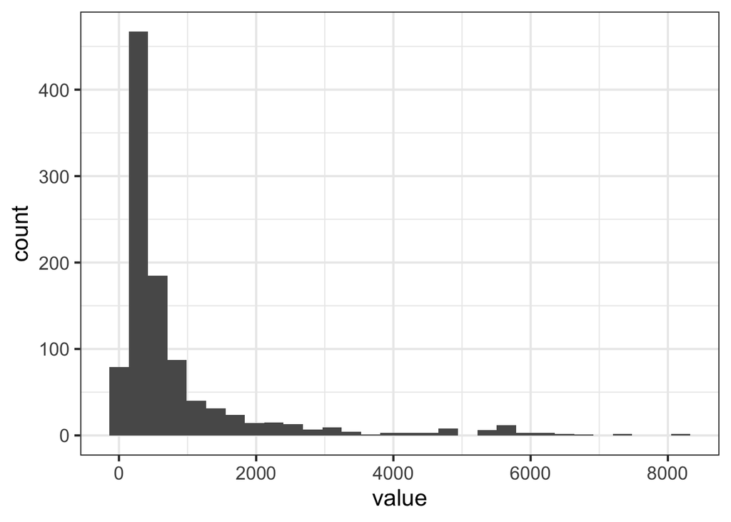

```r
data_qsar_mtx <- data_qsar |>
  select(-class) |>
  as.matrix()

features <- colSums(data_qsar_mtx) |>
  enframe()

features |>
  ggplot(aes(x = value)) +
  geom_histogram()
```

So there are many featurs that are represented in the data at low frequencies and very few features that are respresented in the data very often.

Let’s see how these distributions look if we split for negative and positive compounds

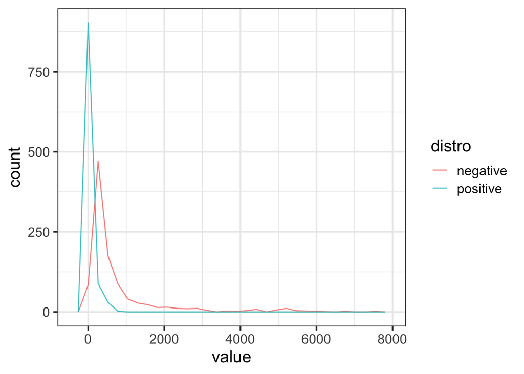

```r
features_negative <- data_qsar |>
  dplyr::filter(class == "negative") |>
  select(-class) |>
  as.matrix() |>
  colSums() |>
  enframe() |>
  mutate(distro = "negative")

features_positive <- data_qsar |>
  dplyr::filter(class == "positive") |>
  select(-class) |>
  as.matrix() |>
  colSums() |>
  enframe() |>
  mutate(distro = "positive")

features_neg_pos <- dplyr::bind_rows(
  features_negative,
  features_positive
)

features_neg_pos |>
  ggplot(aes(x = value)) +
  geom_freqpoly(aes(colour = distro), alpha = 0.8)
```

##### Exercise 5

Are there differences in total amount of features between positive and negative compounds?

Be aware, that we have more negtives then positives in our data. Can you think of a way to normalize for this?

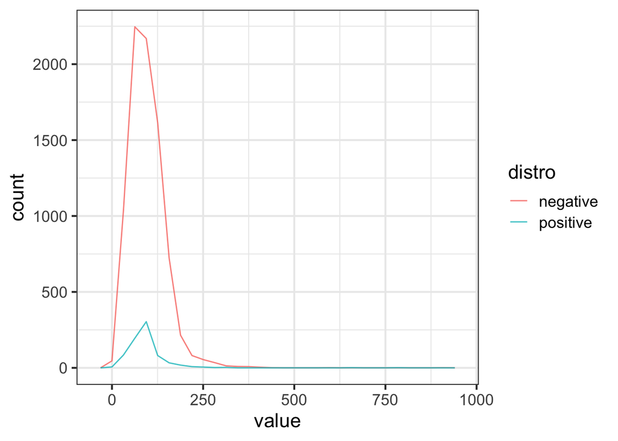

```r
data_qsar |>
  group_by(class) |>
  tally() -> tally_compounds

features_row_neg <- data_qsar |>
  dplyr::filter(class == "negative") |>
  select(-class) |>
  as.matrix() |>
  rowSums() |>
  enframe() |>
  mutate(distro = "negative")

features_row_pos <- data_qsar |>
  dplyr::filter(class == "positive") |>
  select(-class) |>
  as.matrix() |>
  rowSums() |>
  enframe() |>
  mutate(distro = "positive")

features_row_neg_pos <- dplyr::bind_rows(
  features_row_neg,
  features_row_pos
)

features_row_neg_pos |>
  ggplot(aes(x = value)) +
  geom_freqpoly(aes(colour = distro), alpha = 0.8)
```

```r
features_row_neg_pos |>
  group_by(distro) |>
  summarise(mean_feat = mean(value))
```

```
## # A tibble: 2 × 2
##   distro   mean_feat
##   <chr>        <dbl>
## 1 negative      95.6
## 2 positive      91.4
```

On average, there is not much difference in number of features per compound, if we compare negatives and positives

### Sparsity

As we saw upon first inspection of the data, the fingerprints contain only 2 values: a `1` and a `0`. One of the disadvantages of describing molecules on the basis of fingerprints is that the resulting matrix is *sparse*. This means that there is relatively lo information content (many zeros and a few ones) in the data. Let’s calculate how sparse the matrix is. We will write a function that we can recycle.

```r
df = data_qsar
only_numeric <- select_if(df, is.numeric)
number_numeric_cells <- (nrow(df) * ncol(df))
number_zeros <- sum(df == 0)
number_ones <- sum(df == 1)
sparsity = (number_ones / number_zeros)*100

## Let's put this together in a function, we write a test to check for input

get_sparsity_perc <- function(df){

  only_numeric <- select_if(df, is.numeric)
  only_numeric_mtx <- only_numeric |> as.matrix()

  ## check if values of matrix are either 0 or 1
  ## %in% is functional for `match`
  if(
      only_numeric_mtx %in% c(0,1) |>
      all() == FALSE){
    stop("Please check if input values are either ones               and/or zeros")
   }

  number_numeric_cells <- (nrow(df) * ncol(df))
  number_zeros <- sum(df == 0)
  number_ones <- sum(df == 1)
  sparsity = (number_ones / number_zeros)*100
  return(sparsity)

}

## test function
get_sparsity_perc(df = data_qsar)

## check our test
data_qsar_with_mutation <- data_qsar
data_qsar_with_mutation[333,445] <- 9.887
get_sparsity_perc(data_qsar_with_mutation)

## getting unique values
select_if(data_qsar, is.numeric) |>
map(unique) |>
  unique() |>
  flatten() |>
  unique()

select_if(data_qsar_with_mutation, is.numeric) |>
map(unique) |>  unique() |>
  flatten() |>
  unique()
```

### Heatmap

Let’s look at the fingerprints and see how they differ between negatives and positives. Maybe we can learn something there. Because we have many features and observations, we will take a random sample, to reduce computation time

```r
set.seed(123)
data_qsar_sample <- data_qsar |>
  mutate(row_id = 1:nrow(data_qsar)) |>
  sample_frac(0.005)

data_qsar_mtx_sample <- data_qsar_sample |>
  select(-class) |>
  as.matrix()

colnames(data_qsar_mtx_sample) <- paste0(
  "c",
  1:ncol(data_qsar_mtx_sample)
  )

pheatmap::pheatmap(data_qsar_mtx)


data_qsar_sample |>
  pivot_longer(cols = f1:f1024, values_to = "score", names_to = "feature") |>
  ggplot(aes(
    x = reorder(as_factor(feature), score),
    y = as_factor(score))) +
  geom_tile(aes(fill = as_factor(score))) + facet_wrap(class~row_id) +
  xlab(NULL) +
  ylab(NULL) +
  theme(axis.title.x=element_blank(),
        axis.text.x=element_blank(),
        axis.ticks.x=element_blank(),
        strip.text.x = element_text(size = 4))


ggsave("test.svg", height = 20, width = 20, units = "cm", dpi = 300)
```

## Unsupervised machine learning

Before we plan to do any kind of classification task on our data, it is good to consider doing an exploratory data analysis to learn more about our data. Here we use a principal component analysis and a k-means clustering to learn some patterns.

## Principal Component Analysis

For code see: https://cmdlinetips.com/2020/06/pca-with-tidymodels-in-r/

```r
library(tidymodels)
library(tidyverse)
#library(gapminder)
theme_set(theme_bw(16))
```

```r
pca_recipe <- recipe(~., data = data_qsar)
pca_trans <- pca_recipe %>%
  # center the data
  step_center(all_numeric()) %>%
  # center the data
  step_scale(all_numeric()) %>%
  # pca on all numeric variables
  step_pca(all_numeric())

pca_estimates <- prep(pca_trans) ## this step takes a bit longer to calculate
pca_estimates$var_info
sdev <- pca_estimates$steps[[3]]$res$sdev
percent_variation <- sdev^2 / sum(sdev^2)

var_df <- data.frame(PC=paste0("PC",1:length(sdev)),
                     var_explained=percent_variation,
                     stringsAsFactors = FALSE)

var_df %>%
  mutate(PC = fct_inorder(PC)) %>%
  ggplot(aes(x=PC,y=var_explained))+geom_col()

juice(pca_estimates)
juice(pca_estimates) %>%
  ggplot(aes(PC1, PC2)) +
  geom_point(aes(color = class), alpha = 0.3, size = 2)+
  labs(title="PCA from tidymodels")
```

```r
#install.packages("embed")
library(embed)
pca_recipe <- recipe(~., data = data_qsar)
pca_trans <- pca_recipe %>%
  # center the data
  step_center(all_numeric()) %>%
  # center the data
  step_scale(all_numeric()) %>%
  # pca on all numeric variables
  step_umap(all_numeric())

pca_estimates <- prep(pca_trans) ## this step takes a bit longer to calculate
pca_estimates$var_info
```

```
## # A tibble: 1,025 × 4
##    variable type    role      source
##    <chr>    <chr>   <chr>     <chr>
##  1 class    nominal predictor original
##  2 f1       numeric predictor original
##  3 f2       numeric predictor original
##  4 f3       numeric predictor original
##  5 f4       numeric predictor original
##  6 f5       numeric predictor original
##  7 f6       numeric predictor original
##  8 f7       numeric predictor original
##  9 f8       numeric predictor original
## 10 f9       numeric predictor original
## # … with 1,015 more rows
```

```r
juice(pca_estimates)
```

```
## # A tibble: 8,992 × 3
##    class    UMAP1 UMAP2
##    <fct>    <dbl> <dbl>
##  1 negative  1.57  3.81
##  2 negative  1.67  3.67
##  3 negative  1.72  3.66
##  4 negative  1.69  3.67
##  5 negative  1.12  1.36
##  6 negative  1.87  2.97
##  7 negative  2.38  3.36
##  8 positive -5.70 -3.57
##  9 negative -5.48 -3.49
## 10 negative -4.71 -5.28
## # … with 8,982 more rows
```

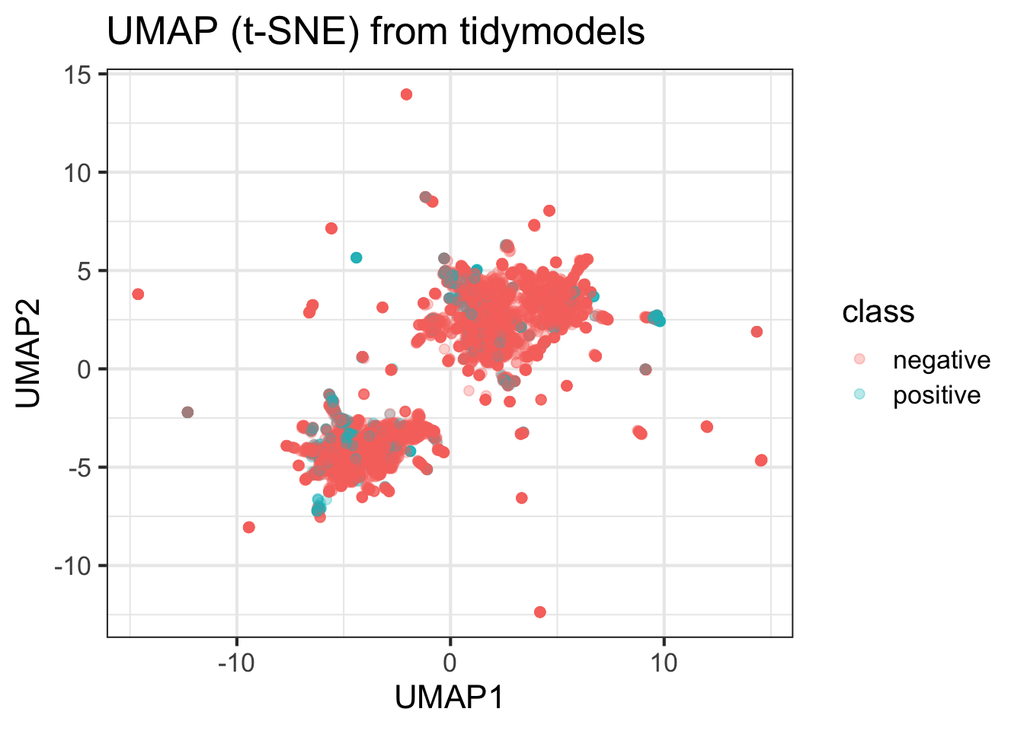

```r
juice(pca_estimates) %>%
  ggplot(aes(UMAP1, UMAP2)) +
  geom_point(aes(color = class), alpha = 0.3, size = 2)+
  labs(title="UMAP (t-SNE) from tidymodels")
```

## K-means clustering

https://uc-r.github.io/kmeans_clustering

```r
library(tidyverse)  # data manipulation
library(cluster)    # clustering algorithms
library(factoextra)

set.seed(123)
data_qsar_k <- data_qsar |>
  sample_frac(0.1) |>
  as.data.frame()

row_names <- paste(c(1:nrow(data_qsar_k)), data_qsar_k$class, sep = "_")

rownames(data_qsar_k) <- row_names

data_qsar_k <- data_qsar_k |>
  select(-class)

df <- scale(data_qsar_k)
df
distance <- get_dist(df)

sum(is.na(df))
sum(is.na(data_qsar_sample))

## takes a long time to compute
fviz_dist(
  distance,
  gradient = list(
    low = "#00AFBB",
    mid = "white",
    high = "#FC4E07"
    )
  )

k2 <- kmeans(df, centers = 2)
fviz_cluster(k2, data = df)


## Multiple clusters
k3 <- kmeans(df, centers = 3, nstart = 25)
k4 <- kmeans(df, centers = 4, nstart = 25)
k5 <- kmeans(df, centers = 5, nstart = 25)

p1 <- fviz_cluster(k2, geom = "point", data = df) + ggtitle("k = 2")
p2 <- fviz_cluster(k3, geom = "point",  data = df) + ggtitle("k = 3")
p3 <- fviz_cluster(k4, geom = "point",  data = df) + ggtitle("k = 4")
p4 <- fviz_cluster(k5, geom = "point",  data = df) + ggtitle("k = 5")

library(gridExtra)
grid.arrange(p1, p2, p3, p4, nrow = 2)

set.seed(123)
fviz_nbclust(df, kmeans, method = "wss")
fviz_nbclust(df, kmeans, method = "silhouette")
set.seed(123)
```

## Regression tree

Beause we have class imbalance we use a stratification approach

```r
## prepare data splits
set.seed(123)
qsar_split <- initial_split(data = data_qsar,
                             prop = 0.80, strata = class)
qsar_train <- training(qsar_split)
qsar_test <- testing(qsar_split)
```

Let’s look at the tally https://r4ds.github.io/bookclub-tmwr/class-imbalance.html

```r
qsar_test |>
  group_by(class) |>
  tally()
```

```
## # A tibble: 2 × 2
##   class        n
##   <chr>    <int>
## 1 negative  1665
## 2 positive   134
```

```r
qsar_train |>
  group_by(class) |>
  tally()
```

```
## # A tibble: 2 × 2
##   class        n
##   <chr>    <int>
## 1 negative  6586
## 2 positive   607
```

## Random Forest

https://deepai.org/machine-learning-glossary-and-terms/random-forest https://juliasilge.com/blog/sf-trees-random-tuning/ https://www.r-bloggers.com/2020/04/predicting-large-and-imbalanced-data-set-using-the-r-package-tidymodels/

```r
## prepare model recipe
rf <- rand_forest(trees = 10) %>%
  set_engine("ranger", num.threads=3, seed = 123) %>%
  set_mode("classification")

rf_rec <- recipe(class ~ ., data = qsar_train)
#%>%
#  update_role(class, new_role = "ID")

rf_wf <- workflow() %>%
  add_model(rf) %>%
  add_recipe(rf_rec)

prep <- prep(rf_rec)
juiced <- juice(prep)

data_qsar <- data_qsar |>
  mutate(class = as_factor(class))

qsar_test <- qsar_test |>
  mutate(class = as_factor(class))

qsar_train <- qsar_train |>
  mutate(class = as_factor(class))

set.seed(1)

## fit model
model_rf <- rf_wf %>%
  fit(data = qsar_train)

## see model metrics

model_rf %>% extract_fit_parsnip()
```

```
## parsnip model object
##
## Ranger result
##
## Call:
##  ranger::ranger(x = maybe_data_frame(x), y = y, num.trees = ~10,      num.threads = ~3, seed = ~123, verbose = FALSE, probability = TRUE)
##
## Type:                             Probability estimation
## Number of trees:                  10
## Sample size:                      7193
## Number of independent variables:  1024
## Mtry:                             32
## Target node size:                 10
## Variable importance mode:         none
## Splitrule:                        gini
## OOB prediction error (Brier s.):  0.06040722
```

```r
predict(model_rf, qsar_test)
```

```
## # A tibble: 1,799 × 1
##    .pred_class
##    <fct>
##  1 negative
##  2 negative
##  3 negative
##  4 negative
##  5 negative
##  6 negative
##  7 negative
##  8 negative
##  9 negative
## 10 negative
## # … with 1,789 more rows
```

```r
## Model eval
model_rf %>%
  predict( new_data = qsar_test) %>%
  bind_cols(qsar_test["class"]) %>%
  accuracy(truth= as.factor(class), .pred_class)
```

```
## # A tibble: 1 × 3
##   .metric  .estimator .estimate
##   <chr>    <chr>          <dbl>
## 1 accuracy binary         0.948
```

```r
## confusion matrix
caret::confusionMatrix(
  as.factor(qsar_test$class),
  predict(model_rf, new_data = qsar_test)$.pred_class)
```

```
## Confusion Matrix and Statistics
##
##           Reference
## Prediction negative positive
##   negative     1654       11
##   positive       83       51
##
##                Accuracy : 0.9477
##                  95% CI : (0.9364, 0.9576)
##     No Information Rate : 0.9655
##     P-Value [Acc > NIR] : 1
##
##                   Kappa : 0.4967
##
##  Mcnemar's Test P-Value : 2.423e-13
##
##             Sensitivity : 0.9522
##             Specificity : 0.8226
##          Pos Pred Value : 0.9934
##          Neg Pred Value : 0.3806
##              Prevalence : 0.9655
##          Detection Rate : 0.9194
##    Detection Prevalence : 0.9255
##       Balanced Accuracy : 0.8874
##
##        'Positive' Class : negative
##
```

```r
bind_cols(
    predict(model_rf, qsar_test),
    predict(model_rf, qsar_test, type = "prob"),
    qsar_test[,1]
  ) -> predictions
```

see also: https://www.kirenz.com/post/2021-02-17-r-classification-tidymodels/#random-forest

## Tune the model

Above we arbitrarily chose trees = 10, this is called a hyperparameter. We can more structurally tune our model when we do a grid search for the optimal hyperparameters

other hyperparamters for RF

##### Exercise 5

Usually, datasets like the QSAR dataset or Tox21, when making them suitable for Machine Learning they are shared as data split in a file containing the features and a file containing the row descriptors. In the case of Tox21 data, the files are downloadable as files containing the train and test splits of the data, and additional row descriptors. Here we will try to enrich the QSAR data with data from the Tox21 dataset, and use that new dataset to train a new (and hopefully better) model.

**TIPS**

- Use the `janitor::clean_names()` function to create nice (Linux and R safe) headers.

**Click for the answer**

```r
## Packages
library(tidyverse)
library(webchem)

## Read original datasets
# fingerprints
data_fp <- read_csv(
  here::here(
    "data",
    "lesson5",
    "qsar",
    "X.csv"
  ), col_names = paste0("f", 1:1024)
)
# headers
data_x_headers <- read_csv(
  here::here(
    "data",
    "lesson5",
    "qsar",
    "headers_x.txt"
  ), comment = "##"
)
# row id
data_rows <- read_csv(
  here::here(
    "data",
    "lesson5",
    "qsar",
    "ID.txt"
  ), col_names = data_x_headers$colname) |>
  janitor::clean_names() |>
  mutate(
    class = ifelse(
      toxic == "TRUE",
      yes = "positive",
      no = "negative"
    )
  ) |>
  relocate(class, 1)
# join
data_all_qsar <- dplyr::bind_cols(data_rows, data_fp)
```

## Enrichment with data from Tox21

Here we enrich the data, with data from the Tox21 dataset. We have prepared our QSAR data above during the exercise. The combined QSAR data, we will use here further to train a new (and hopefully improved) prediction model for toxicity.

Get Tox21 dataset from Open Chem (https://mariewelt.github.io/OpenChem/html/installation_instructions.html)

see for chemical fingerprints etc. : https://www.rdkit.org/docs/Install.html#how-to-install-rdkit-with-conda

```r
tox21 <- read_csv(  "https://raw.githubusercontent.com/Mariewelt/OpenChem/master/benchmark_datasets/tox21/tox21.csv")
ind <- tox21$smiles %in% data_all_qsar$canonical_qsa_rr

tox21[ind,]
```

```
## # A tibble: 1,155 × 14
##    `NR-AR` `NR-AR-LBD` `NR-AhR` `NR-Aromatase` `NR-ER` `NR-ER-LBD` NR-PPAR…¹ SR-AR…² SR-AT…³ SR-HS…⁴ SR-MM…⁵ SR-p5…⁶ mol_id smiles
##      <dbl>       <dbl>    <dbl>          <dbl>   <dbl>       <dbl>     <dbl>   <dbl>   <dbl>   <dbl>   <dbl>   <dbl> <chr>  <chr>
##  1       0           0        0              0       0           0         0      NA       0       0       0       0 TOX51… CC(C)…
##  2       0           0        0              0       0           0         0       0       0       0       0       0 TOX66… CC(C)…
##  3       0           0        0              0       0           0         0       0       0       0       0       0 TOX18… CC(O)…
##  4       0           0        0              0       0           0         0       0       0       0       0       0 TOX18… CC(C)…
##  5       0          NA        1             NA      NA           0        NA       1       0       0       1       1 TOX11… Oc1c(…
##  6       0           0        1              0       0          NA         0       0       0       0      NA       0 TOX22… CNC(=…
##  7       0           0        0              0       0           0         0       0       0       1       0       0 TOX22… CCCCN…
##  8       0           0        0              0       0           0         0       0       0       0       0       0 TOX10… CC(=O…
##  9       0           0        0              0       0           0         0       0       0       0       0       0 TOX21… N#CCC…
## 10       0           0        0              0       0           0         0       0       0       0       0       0 TOX27… Cc1nc…
## # … with 1,145 more rows, and abbreviated variable names ¹`NR-PPAR-gamma`, ²`SR-ARE`, ³`SR-ATAD5`, ⁴`SR-HSE`, ⁵`SR-MMP`,
## #   ⁶`SR-p53`
```

```r
joined <-  left_join(data_all_qsar, tox21, by = c("canonical_qsa_rr" = "smiles"))
```

## New model

Steps:

1. Create embeddings for tox21
2. Train new model using XGBoost
3. Train on each assay as outcome
4. Predict target for qsar data. Can we ascribe toxicity to a target?

## Create structural embedding with a Transformer

Creating different embeddings from molecule structure Thanks to Tom Luechtefeld (Sysrev.com) for providing this code and demo.

https://mariewelt.github.io/OpenChem/html/tutorials/tox21_tutorial.html https://docs.conda.io/en/latest/miniconda.html For Apple (M1): https://developer.apple.com/metal/tensorflow-plugin/ (tensorflow)

```r
reticulate::use_condaenv("DC")
library(reticulate)
library(tidyverse)

# rdkit <- reticulate::import("rdkit")
transformers <- reticulate::import('transformers') # this is a huggingface.co api
#openchem <- reticulate::import("openchem.data.utils")

smi <- tox21$smiles[1]

hface <- "seyonec/ChemBERTa-zinc-base-v1"
tok   <- transformers$AutoTokenizer$from_pretrained(hface)
bert  <- transformers$AutoModel$from_pretrained(hface)

mktokens <- \(smi){
  res <- tok$batch_encode_plus(smi,padding="max_length", max_length=512L)
  enc <- do.call(rbind,map(1:length(smi) - 1, \(i){ res[i]$ids}))
  att <- do.call(rbind,map(1:length(smi) - 1, \(i){ res[i]$attention_mask}))
  list(input_ids=enc, attention_mask=att)
}

embedd <- mktokens(as.list(smi))

data <- readr::read_csv("../cache/train.csv") |>
  filter(stype=="1998110-%-Percent Effect") |>
  mutate(value = ifelse(standard_value>0,1,0)) |>
  head(1000)

tokens <- mktokens(data$canonical_smiles) |> map(~ keras_array(.,dtype="int32"))
embeds <- bert$predict(tokens)[[2]]
norm   <- tf$linalg$normalize(embeds,axis=-1L)[[1]]

sim <- tf$matmul(norm,tf$transpose(norm))
anc <- tibble(anc=data$canonical_smiles)
ana <- tibble(ana=data$canonical_smiles) |> mutate(row=row_number())

hmap <- anc |> full_join(ana,by=character()) |> mutate(sim=array(sim)) |> arrange(-sim) |>
  filter(anc != ana)

smi <- hmap |> pivot_longer(cols=c("anc","ana")) |> filter(sim>0.95,sim<0.99)

res <- callr::r_bg(function(smiles){
  reticulate::use_condaenv("r-reticulate")
  reticulate::source_python('../src/py/draw_mols.py')
  draw_mols(smiles,"output2.svg")
},args=list(smiles=smi$value))
```

```python
import numpy as np
from openchem.data.utils load read_smiles_property_file
data = read_smiles_property_file('./benchmark_datasets/tox21/tox21.csv',
                                 cols_to_read=[13] + list(range(0,12)))
smiles = data[0]
labels = np.array(data[1:])
```

## Adding the features to our qsar data